# Psychotherapy Study

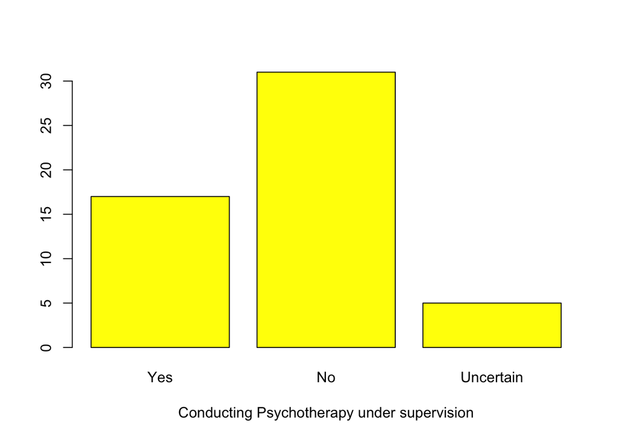

```r
barplot(table(Czech_Republic_data$q_0011_SQ003), col="yellow", xlab="Conducting Psychotherapy under supervision")
```

```r
table(Czech_Republic_data$q_0011_SQ004)
```

```
##
##       Yes        No Uncertain
##         7        39         6
```

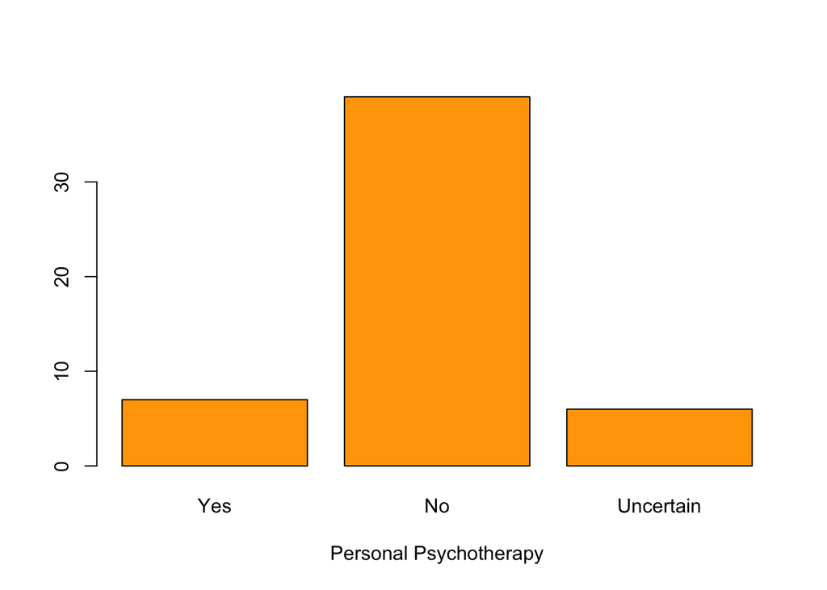

```r
barplot(table(Czech_Republic_data$q_0011_SQ004), col="orange", xlab="Personal Psychotherapy")
```

```r
table(Czech_Republic_data$q_0012)
```

```
##
##    Yes     No Unsure
##     12     36      5
```

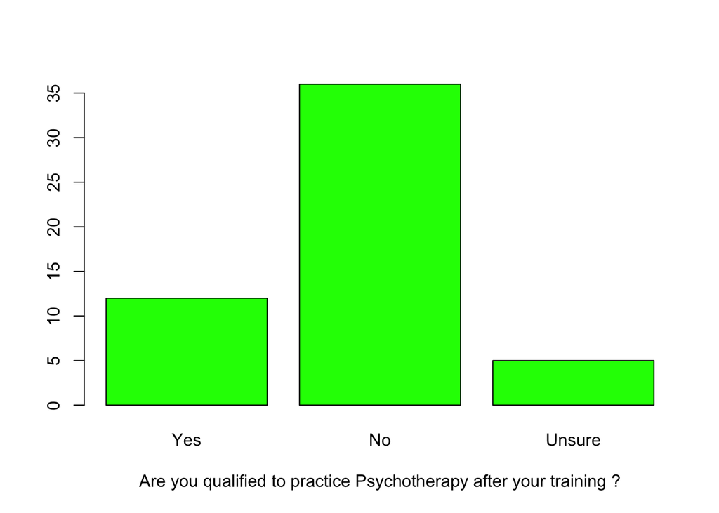

```r
barplot(table(Czech_Republic_data$q_0012), col="green", xlab="Are you qualified to practice Psychotherapy after your training ?")
```

## Plot: How many hours of supervisions

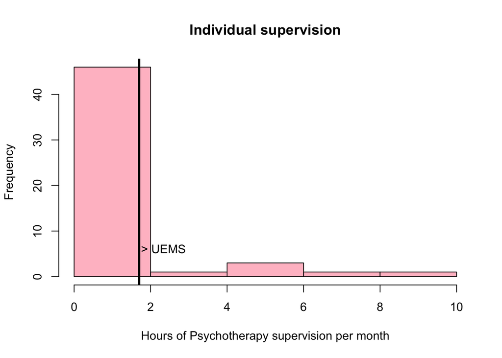

```r
hist(Czech_Republic_data$q_0014_SQ001, col="pink",
     xlab="Hours of Psychotherapy supervision per month",
     main = "Individual supervision",
     breaks=6)
abline(v=1.7, lwd=3)
text(1.75,5, "> UEMS", adj = c(0, -.1))
```

> UEMS Charter on Psychiatry states that minimum duration of psychotherapy supervision should be 100 hours during the whole training of 5 recommended years. It makes 1.7 hours approximatively a month.

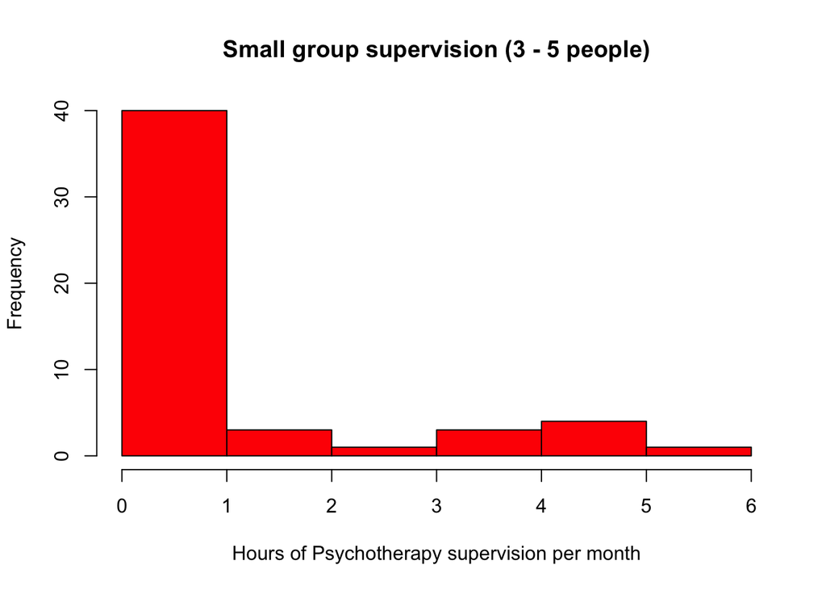

```r
hist(Czech_Republic_data$q_0014_SQ002, col="red",
     main="Small group supervision (3 - 5 people)",
     xlab="Hours of Psychotherapy supervision per month")
```

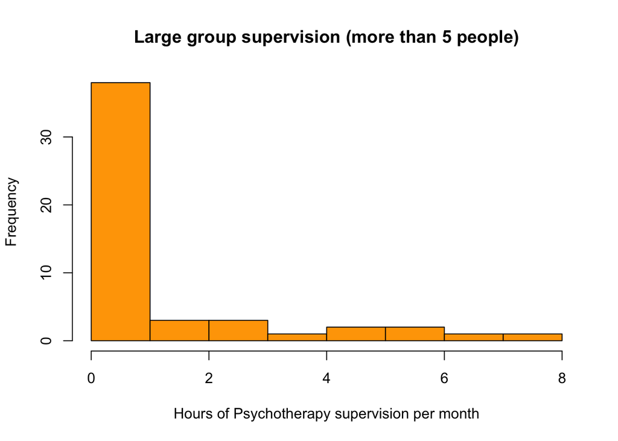

```r
hist(Czech_Republic_data$q_0014_SQ003,
     main="Large group supervision (more than 5 people)",
     xlab="Hours of Psychotherapy supervision per month",
     col= "orange")
```

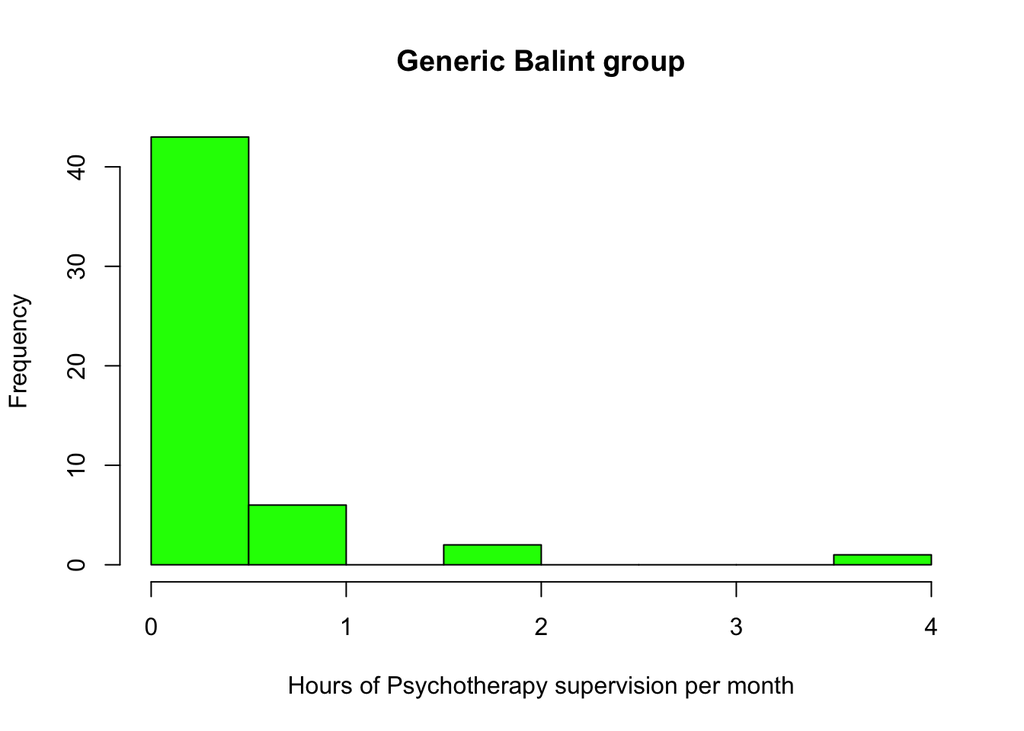

```r
hist(Czech_Republic_data$q_0014_SQ004, col="green",
     xlab= "Hours of Psychotherapy supervision per month",
     main ="Generic Balint group",
     breaks=10)
```

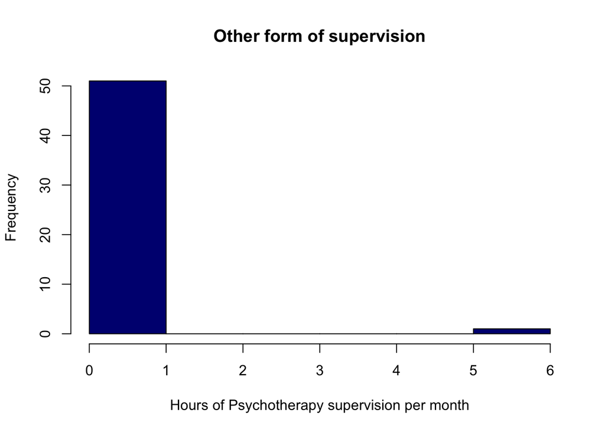

```r
hist(Czech_Republic_data$q_0014_SQ005, col="navy",
     xlab= "Hours of Psychotherapy supervision per month",
     main ="Other form of supervision")
```

table(Czech_Republic_data$q_0015)

## Plot: Who pays?

This again should ba a plot group on one page

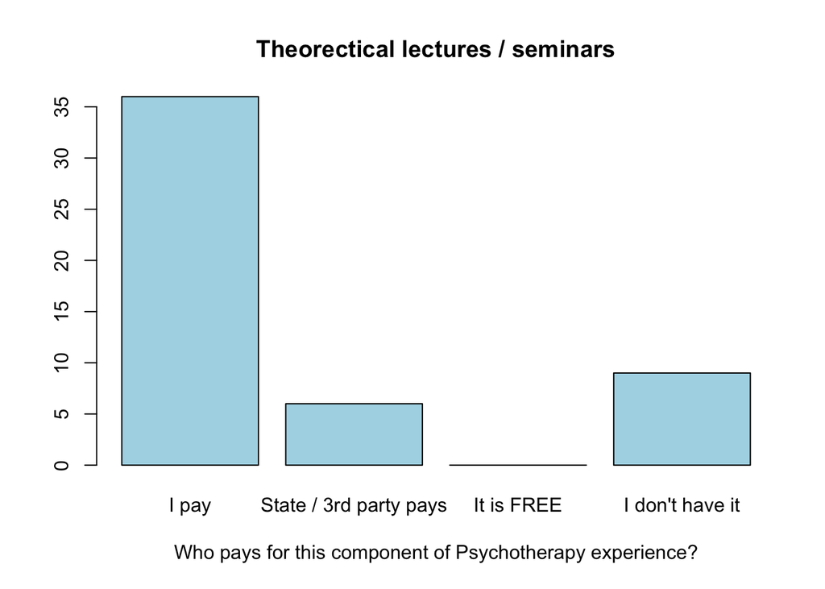

```r
barplot(table(Czech_Republic_data$q_0016_SQ001), col="light blue",
        main="Theorectical lectures / seminars",
        xlab="Who pays for this component of Psychotherapy experience?")
```

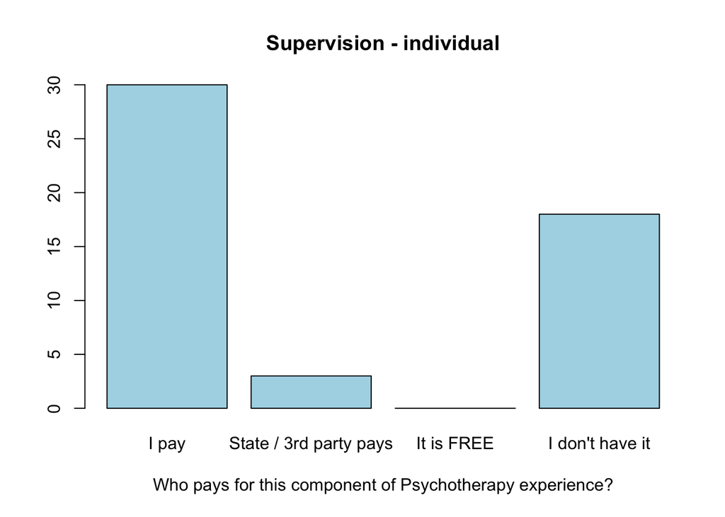

```r
barplot(table(Czech_Republic_data$q_0016_SQ002), col="light blue",
        xlab="Who pays for this component of Psychotherapy experience?",
        main="Supervision - individual")
```

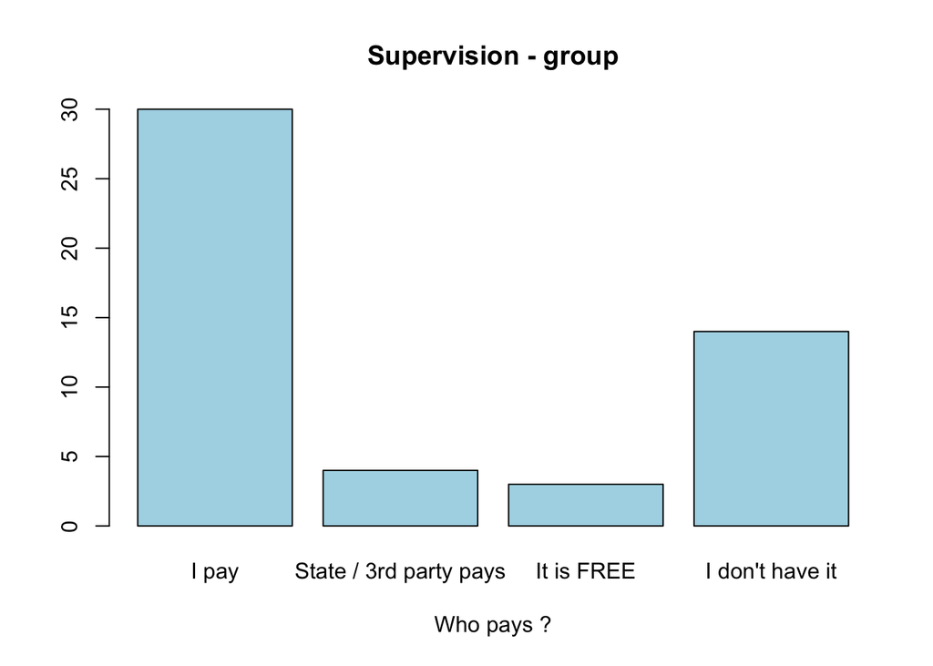

```r
barplot(table(Czech_Republic_data$q_0016_SQ003), col="light blue",
        main="Supervision - group",
        xlab="Who pays ?")
```

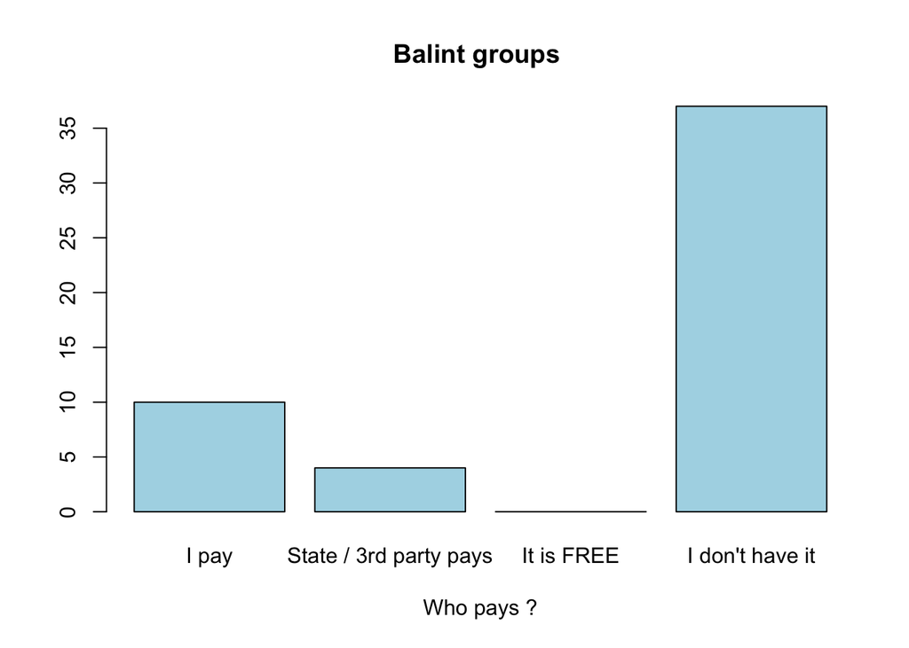

```r
barplot(table(Czech_Republic_data$q_0016_SQ004), col="light blue",
        main="Balint groups ",
        xlab="Who pays ?")
```

[figure not shown]

```r
barplot(table(Czech_Republic_data$q_0016_SQ004), col="light blue",
        main="Sessions with patient(s)",
        xlab="Who pays ?")
```

[figure not shown]

```r
barplot(table(Czech_Republic_data$q_0016_SQ004), col="light blue",
        main="Self-experience",
        xlab="Who pays")
```

## Plot: Would you train for Free ?

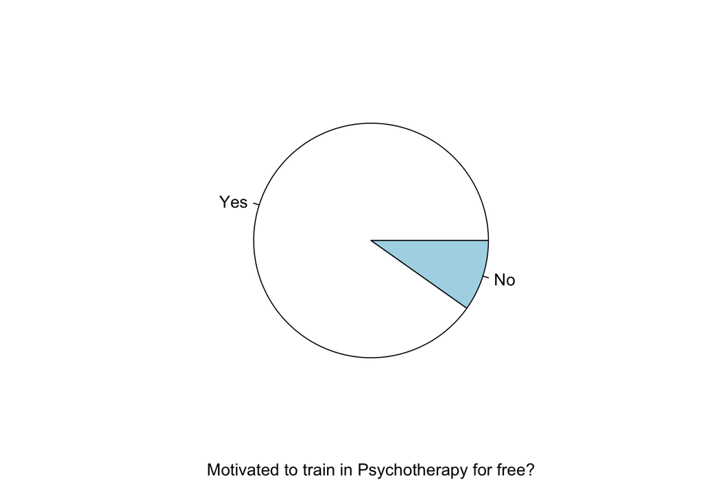

```r
pie(table(Czech_Republic_data$q_0017),
    xlab="Motivated to train in Psychotherapy for free?")
```

UEMS recommendations states that psychotherapy training of trainees should be funded publicly and free for trainees.

## Plot: How much would you invest in psychotherapy training ?

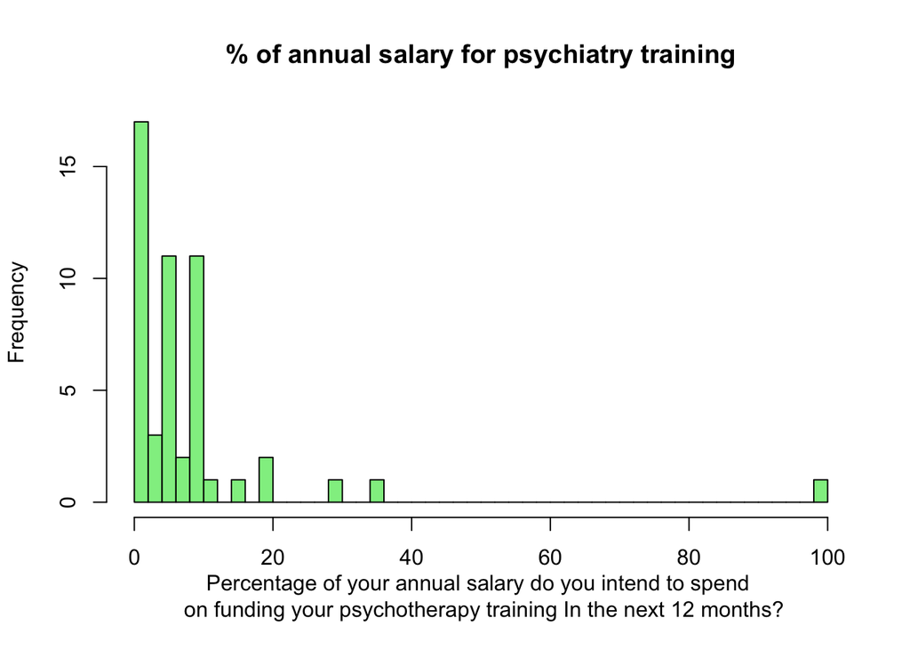

```r
hist(Czech_Republic_data$q_0018, col="light green",
     main="% of annual salary for psychiatry training",
     xlab="Percentage of your annual salary do you intend to spend \n on funding your psychotherapy training In the next 12 months?",
     breaks=c(seq(0,100,2)))
```

## Plot: Satisfaction group

perhaps we should use likert package to plot likert type items

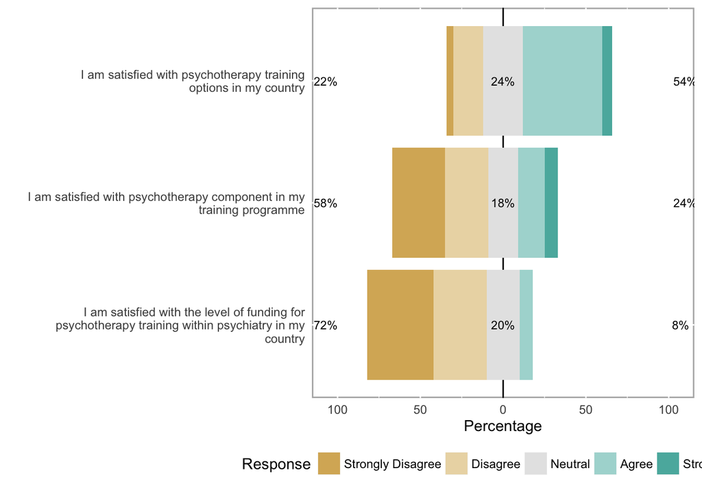

```r
# make auxiliary table to hold our likert Czech_Republic_data
sat1<-Czech_Republic_data[,43:45]
# put in correct row names
sat1 <- rename(sat1,c("q_0019_SQ001"="I am satisfied with psychotherapy component in my training programme",
  "q_0019_SQ002"="I am satisfied with psychotherapy training options in my country",
  "q_0019_SQ003"="I am satisfied with the level of funding for psychotherapy training within psychiatry in my country"
  ))
sat12<-likert(sat1)
plot(sat12)
```

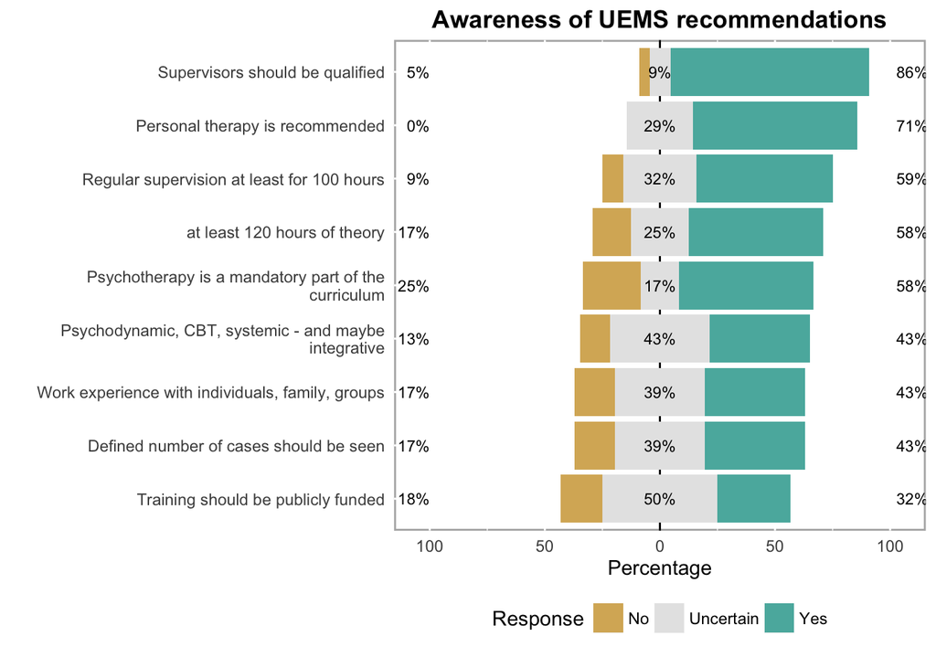

```r
# comment out barplots for now
# barplot(table(Czech_Republic_data$q_0019_SQ001), main ="I am satisfied with Psychotherapy component in my training programme")

# well, let's deal with UEMS bits as with likert scales
uems1 <- Czech_Republic_data[,46:54]
uems1[,1] <- factor(uems1[,1],c("No","Uncertain","Yes"))
uems1[,2] <- factor(uems1[,2],c("No","Uncertain","Yes"))
uems1[,3] <- factor(uems1[,3],c("No","Uncertain","Yes"))
uems1[,4] <- factor(uems1[,4],c("No","Uncertain","Yes"))
uems1[,5] <- factor(uems1[,5],c("No","Uncertain","Yes"))
uems1[,6] <- factor(uems1[,6],c("No","Uncertain","Yes"))
uems1[,7] <- factor(uems1[,7],c("No","Uncertain","Yes"))
uems1[,8] <- factor(uems1[,8],c("No","Uncertain","Yes"))
uems1[,9] <- factor(uems1[,9],c("No","Uncertain","Yes"))
# Put nice column names for the plot
uems1 <- rename(uems1,c(
  q_0021_SQ001="Psychotherapy is a mandatory part of the curriculum",
  q_0021_SQ002="Defined number of cases should be seen",
  q_0021_SQ003="at least 120 hours of theory",
  q_0021_SQ004="Work experience with individuals, family, groups",
  q_0021_SQ005="Psychodynamic, CBT, systemic - and maybe integrative",
  q_0021_SQ006="Personal therapy is recommended",
  q_0021_SQ007="Supervisors should be qualified",
  q_0021_SQ008="Regular supervision at least for 100 hours",
  q_0021_SQ009="Training should be publicly funded"
  ))
## Plot: UEMS recs awareness
uems12 <- likert(uems1)
plot(uems12) +
  ggtitle("Awareness of UEMS recommendations") +
  theme(plot.title = element_text(lineheight=.8, face="bold"))
```

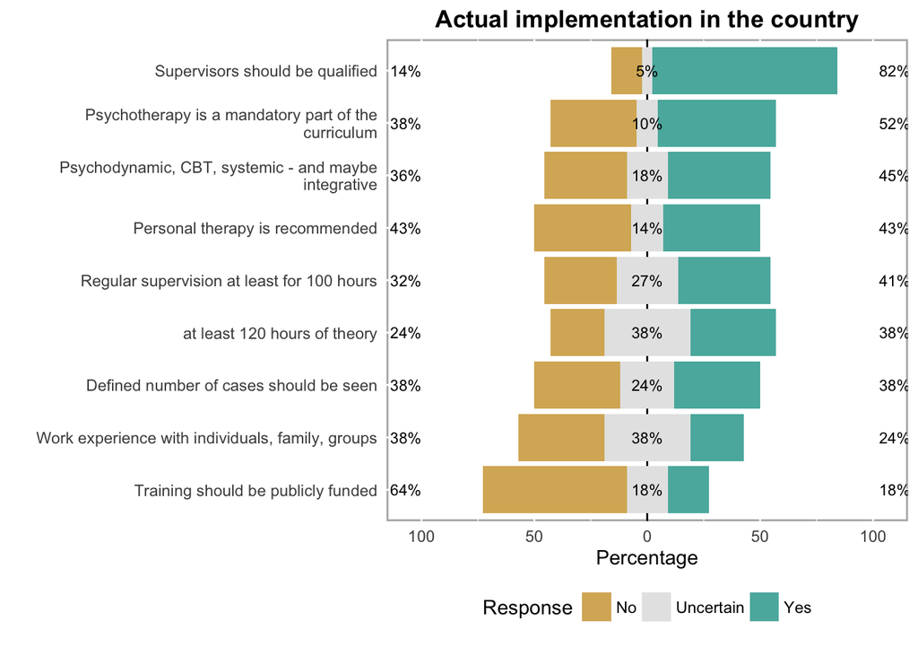

```r
# and same with the
uems2 <- Czech_Republic_data[,55:63]
uems2[,1] <- factor(uems2[,1],c("No","Uncertain","Yes"))
uems2[,2] <- factor(uems2[,2],c("No","Uncertain","Yes"))
uems2[,3] <- factor(uems2[,3],c("No","Uncertain","Yes"))
uems2[,4] <- factor(uems2[,4],c("No","Uncertain","Yes"))
uems2[,5] <- factor(uems2[,5],c("No","Uncertain","Yes"))
uems2[,6] <- factor(uems2[,6],c("No","Uncertain","Yes"))
uems2[,7] <- factor(uems2[,7],c("No","Uncertain","Yes"))
uems2[,8] <- factor(uems2[,8],c("No","Uncertain","Yes"))
uems2[,9] <- factor(uems2[,9],c("No","Uncertain","Yes"))

# Put nice column names for the plot
uems2 <- rename(uems2,c(
  q_0022_SQ001="Psychotherapy is a mandatory part of the curriculum",
  q_0022_SQ002="Defined number of cases should be seen",
  q_0022_SQ003="at least 120 hours of theory",
  q_0022_SQ004="Work experience with individuals, family, groups",
  q_0022_SQ005="Psychodynamic, CBT, systemic - and maybe integrative",
  q_0022_SQ006="Personal therapy is recommended",
  q_0022_SQ007="Supervisors should be qualified",
  q_0022_SQ008="Regular supervision at least for 100 hours",
  q_0022_SQ009="Training should be publicly funded"
))
uems22 <- likert(uems2)
plot(uems22) +
  ggtitle("Actual implementation in the country") +
  theme(plot.title = element_text(lineheight=.8, face="bold"))
```

## Research

UEMS recommendations states that research methodology should be included in psychotherapy training.

## Bibliography

- Please join our [zotero group](https://www.zotero.org/groups/480046)